# London Transport 2024 - Initiatives, Public Communication and Public Transport Usage

Ella Vacic

Fri/28/Mar

## 1. Overview

Despite efforts by the Greater London Authority to promote public transport usage, challenges remain. This report presents new data to understand the correlation between public transport initiatives, public communication of such initiatives and Londoners’ usage of public transport. Primary data, collected from Transport for London (TfL) 2024 press releases, is merged with secondary data from the UK Government outlining daily use of transport modes. The primary data offers insights into government initiatives implemented in relation to transport, as TfL is government-owned, and the manner in which these are communicated with the public; the secondary data provides a broader context of public transport usage in the UK. When compiled, the final dataset allows for a comprehensive analysis of the relationship between government initiatives, public communication, and public transport usage.

## 2. TfL Press Releases 2024 - London public transport initiatives and communication

Below, press releases from 2024 are scraped from the TfL website as raw text files.

```r
# Load all necessary libraries
library(tidyverse)
library(rvest)
library(stringr)
library(RSelenium)
library(httr)
library(readr)
library(dplyr)
library(lubridate)
library(tidyr)
library(quanteda)
library(ggplot2)
library(knitr)
library(patchwork)
```

```r
# Create a folder to store the data
data_folder <- "data/"
# Check if the folder exists and create it if necessary
if(!dir.exists(data_folder)) { dir.create(data_folder) }

# Create subfolder for text files
subfolder <- paste0(data_folder, "tfl_press_releases_2024")
# Check if the folder exists and create it if necessary
if(!dir.exists(subfolder)) { dir.create(subfolder) }
```

```r
# Set URL for the TfL 2024 press releases page
tfl_url_2024 <- "https://tfl.gov.uk/info-for/media/press-releases/2024"

# Start the Selenium server
rD <- rsDriver(browser=c("firefox"), verbose = FALSE,
               port = netstat::free_port(random = TRUE))

# Create a client
driver <- rD$client

# Navigate to the TfL press releases page
driver$navigate(tfl_url_2024)
Sys.sleep(2)

# Accept cookies
accept_button <- driver$findElement(using = "xpath",
                                      '//*[(@id = "CybotCookiebotDialogBodyLevelButtonLevelOptinAllowAll")]//strong')
Sys.sleep(2)
accept_button$clickElement()
Sys.sleep(2)
```

```r
# Define the list of month names
months <- c("january", "february", "march", "april", "may", "june",
            "july", "august", "september", "october", "november", "december")

# Check if there are files in the subfolder
if (length(list.files(subfolder)) == 0) {

  # If there are no files, run the code
  for (i in 1:12) {

  # Concstruct the url for that specific month, to later navigate back to it
  month_url <- paste0("https://tfl.gov.uk/info-for/media/press-releases/2024/", months[i])

  # Attempt to click close button for the survey popup
  tryCatch({
    survey_close <- driver$findElement(using = "xpath", '//xpath-to-close-survey-button')
    Sys.sleep(2)
    survey_close$clickElement()
    Sys.sleep(2)
    }, error = function(e) {
      # Do nothing if the popup doesn't appear
      })

  # Navigate to the constructed URL
  driver$navigate(month_url)
  Sys.sleep(2)

  # Read the page source
  month_page_source <- driver$getPageSource()[[1]]
  Sys.sleep(2)
  month_page_html <- read_html(month_page_source)

  # Count the number of press releases
  plain_button_count <- month_page_html %>%
    html_elements(css = ".plain-button") %>%
    length()

  # Navigate to the press release page
  for (j in 1:plain_button_count) {

    # Skip the 4th press release on the 3rd month as the page is unavailable
    if (i == 3 && j == 4) {
      next
      }

    # Attempt to click close button for the survey popup
    tryCatch({
      survey_close <- driver$findElement(using = "xpath", '//xpath-to-close-survey-button')
      Sys.sleep(2)
      survey_close$clickElement()
      Sys.sleep(2)
      }, error = function(e) {
        # Do nothing if the popup doesn't appear
        })

    # Identify and click the css selector for the press release button
    press_release_css_selector <- paste0(".vertical-button-container:nth-child(", j, ") .plain-button")
    press_release <- driver$findElement(using = "css selector",
                                          press_release_css_selector)
    Sys.sleep(2)
    press_release$clickElement()
    Sys.sleep(2)

    # Read the page source
    press_page_source <- driver$getPageSource()[[1]]
    Sys.sleep(2)
    press_page_html <- read_html(press_page_source)

    # Extract the press release text
    press_release <- press_page_html %>%
      html_elements(css = "#full-width-content") %>%
      html_text()

    # Save the press release to a file
    file_name <- paste0(months[i], "-", j ,".txt")

    # Save the file in the subfolder folder created earlier
    writeLines(press_release, file.path(subfolder, file_name))

    # Navigate back to the page with all press releases for that month
    # Navigate to the constructed URL
    driver$navigate(month_url)
    Sys.sleep(2)
    }

  # Go back to the page with all months
  driver$navigate(tfl_url_2024)
  Sys.sleep(2)
  }
}
```

```r
# Close the browser
driver$close()

# Stop the Selenium server
rD$server$stop()
```

```
## [1] TRUE
```

The code above is in line with the guidelines and legal requirements of the TfL website set out in their T&C and robots.txt file. To avoid overloading servers or users being blocked from the website, a delay of 2 seconds, replicating human speed, occurs between requests to ensure an acceptable amount of requests are made over time.

## 3. UK Government data - London transport usage

Data on daily domestic transport use across transport modes, each represented as a percentage of the respective transport mode usage levels a few years ago (pre-covid), is collected from the UK Government Open Data Portal. This data supplements that collected above by providing insight into real-life responses to TfL communications, and as such the initiatives implemented by the Greater London Authority, accurate to the day.

```r
# Define the endpoint, given by the API documentation
endpoint <- "https://data.gov.uk/api/action/"

# Search for relevant datasets, following parameters given by the API documentation
query <- "road-traffic"
organization <- "organization:department-for-transport"
# Make the request
response <- GET(paste0(endpoint, "package_search?q=", query, "&fq=", organization))
# Parse the response
search_results <- content(response, "parsed")
# Upon inspection, the second result is the desired id
dataset_id <- search_results$result$results[[1]]$name

# Investigate a specific dataset, following parameters given by the API documentation
# Make the request
response <- GET(paste0(endpoint, "package_show?id=", dataset_id))
# Parse the response
dataset_info <- content(response, "parsed")
# Save the desired data URL, which is the 6th resource
data_url <- dataset_info$result$resources[[2]]$url
```

```r
# Extract the download link using RSelenium
# Start the Selenium server
rD <- rsDriver(browser=c("firefox"), verbose = FALSE,
               port = netstat::free_port(random = TRUE))

# Create a client
driver <- rD$client

# Navigate to the data page URL
driver$navigate(data_url)
Sys.sleep(10)

# Identify and click the dataset info page link
dataset_info_link <- driver$findElement(using = "css selector",
                                    "li:nth-child(1) strong .govuk-link")
Sys.sleep(10)
dataset_info_link$clickElement()
Sys.sleep(10)

# Identify and click on the dataset link
data_link <- driver$findElement(using = "css selector",
                                 ".govuk-\\!-margin-bottom-6~ .govuk-\\!-margin-bottom-6+ .govuk-\\!-margin-bottom-6 .gem-c-attachment__metadata .govuk-link")

Sys.sleep(10)
data_link$clickElement()
Sys.sleep(10)

# Extract the download link
dataset_download_url <- driver$getCurrentUrl()

# Close the browser
driver$close()
rD$server$stop()
```

```
## [1] TRUE
```

```r
# Clean the download URL
dataset_download_url <- dataset_download_url[[1]]
dataset_download_url <- str_remove(dataset_download_url, "/preview$")

# Get the file path from the URL
data_file <- str_extract(dataset_download_url, "([^/]+)$")
data_file <- paste0(data_folder, data_file)

# Download the file
if(!file.exists(data_file)) { download.file(dataset_download_url, data_file) }

# Read the data in the data folder
daily_transport_use_data <- read_csv("data/full_data_clean.csv")
```

As per the documentation, no API key is required to collect data from the UK Government Open Data Portal, making the data collection reproducible by others. To make API requests, the official endpoint given in documentation is used. Although there are no rate limits for the API, a delay of 10 seconds is added between requests when using RSelenium, as per the robots.txt file. Furthermore, the use of RSelenium is in compliance with relevant robots.txt files.

## 4. London transport data 2024 - Compiling the data

The raw text files are now cleaned to extract the desired information (date, title, body). The primary and secondary data are then merged into a single, tidy, tabular dataset.

```r
# Extract the desired information of each press release and put it into tabular format
press_releases_files <- list.files(subfolder, full.names = TRUE)
press_releases_data <- lapply(press_releases_files, readLines)

# Function to extract desired information from each press release
parse_file <- function(text_lines) {
  #
  # Takes a list of text lines as input
  # Extracts the date, title, and body of the press release
  # Returns a named list with the extracted information
  #

  # Combine text lines into single string
  text <- paste(text_lines, collapse = "\n")

  # Extract fields using regular expressions
  new_date <- str_extract(text, "\\d{1,2} [A-Za-z]+ \\d{4}")
  new_title <- str_extract(text,
                           "^[\\s\\S]*?(?=\\n \\n \\n \\n \\n \\n \\n \\n \\n \\n \\n \\n \\n \\n \\n \\n\\n \\n)")
  new_title <- str_split(new_title, "\n")[[1]]
  new_title <- tail(new_title, 1)
  new_body <- str_match(text,
                        "\\d{1,2} [A-Za-z]+ \\d{4}\\s*\\n+\\s*([\\s\\S]*?)(?=\\n+\\s*Notes to Editor)")[, 2]

    if (is.na(new_body)) {
    # You can decide what to do if body extraction fails:
    # Option 1: Extract another part of the text as body (alternative method)
    new_body <- str_match(text,
                          "\\d{1,2} [A-Za-z]+ \\d{4}\\s*\\n+\\s*([\\s\\S]*?)(?=\\n+\\s*Notes to editors)")[, 2]

    # Option 2: Set a default value for the body if extraction fails
    if (is.na(new_body)) {
      new_body <- str_match(text, "\\d{1,2} [A-Za-z]+ \\d{4}\\s*\\n+\\s*([\\s\\S]*?)(?=\\n+\\s*Media navigation)")[, 2]
    }
  }

  # Return as a named list
  list(full_date = new_date,
       title = new_title,
       body = new_body)
}

# Apply the function to all press releases
press_releases_parsed <- lapply(press_releases_data, parse_file)

# Convert to a data frame
tfl_data <- bind_rows(press_releases_parsed)
```

```r
# Turn dates in TfL data into date format to merge on date
tfl_data <- tfl_data %>%
  mutate(date = dmy(full_date)) %>%
  select(-full_date)

# Turn dates in daily transport use data into date format to merge on date
daily_transport_use_data <- daily_transport_use_data %>%
  mutate(date = dmy(date))

# Merge the TfL data with the daily transport use data
london_transport_data <- tfl_data %>%
  left_join(daily_transport_use_data, by = c("date" = "date"), relationship = "many-to-many")

# Pivot the data to a tidy format without NA column
london_transport_data <- london_transport_data %>%
  pivot_wider(names_from = "transport_type", values_from = "value") %>%
  # Sort the data by date
  arrange(date)
```

```r
# First transformation
london_transport_data <- london_transport_data %>%
  mutate(month = month(date, label = TRUE)) %>%
  # Place variable in desired position
  select(date, month, title, body, everything())
```

The code above adds a variable indicating the month to the dataset, and reorders the dataset to place it in the desired position.

```r
# Second transformation
london_transport_data <- london_transport_data %>%
  mutate(day = wday(date, label = TRUE)) %>%
  # Place variable in desired position
  select(date, day, month, title, body, everything())
```

A variable is added to indicate the day of the week, as this has an effect on average transport usage. The variable is then placed in the desired position in the dataset.

```r
# Third transformation
# Calculate monthly averages
averages <- london_transport_data %>%
  group_by(month) %>%
  summarise(across(c(cars:national_rail_noCR), mean, na.rm = TRUE)) %>%
  mutate(across(-month, .names = "{.col}_avg")) %>%
  select(-"cars", -"light_commercial_vehicles", -"heavy_goods_vehicles", -"all_motor_vehicles", -"tfl_tube", -"tfl_bus", -"bus_excluding_london", -"national_rail", -"national_rail_noCR")

# Join with original data and compute deviations
london_transport_data <- london_transport_data %>%
  full_join(averages, by = "month") %>%
  # Add a variable representing the proportion of each transport type compared to its monthly average
  mutate(
    cars_monthly_prop = cars / cars_avg,
    light_commercial_vehicles_monthly_prop = light_commercial_vehicles / light_commercial_vehicles_avg,
    heavy_goods_vehicles_monthly_prop = heavy_goods_vehicles / heavy_goods_vehicles_avg,
    all_motor_vehicles_monthly_prop = all_motor_vehicles / all_motor_vehicles_avg,
    tfl_tube_monthly_prop = tfl_tube / tfl_tube_avg,
    tfl_bus_monthly_prop = tfl_bus / tfl_bus_avg,
    bus_excluding_london_monthly_prop = bus_excluding_london / bus_excluding_london_avg,
    national_rail_monthly_prop = national_rail / national_rail_avg,
    national_rail_noCR_monthly_prop = national_rail_noCR / national_rail_noCR_avg
  ) %>%
  select(-ends_with("_avg"))
```

As average transport usage can vary by month, the code above adds monthly averages for each transport type and calculates the proportion of each transport type relative to the average. This allows for a more accurate comparison of transport usage across months.

```r
# Fourth transformation

# Calculate yearly averages
yearly_averages <- london_transport_data %>%
  summarise(across(c(cars:national_rail_noCR), mean, na.rm = TRUE)) %>%
  mutate(across(everything(), .names = "{.col}_avg")) %>%
  select(-"cars", -"light_commercial_vehicles", -"heavy_goods_vehicles", -"all_motor_vehicles", -"tfl_tube", -"tfl_bus", -"bus_excluding_london", -"national_rail", -"national_rail_noCR")

# Join with original data and compute proportions
london_transport_data <- london_transport_data %>%
  bind_cols(yearly_averages) %>%
  # Add a variable representing the proportion of each transport type compared to its yearly average
  mutate(
    cars_yearly_prop = cars / cars_avg,
    light_commercial_vehicles_yearly_prop = light_commercial_vehicles / light_commercial_vehicles_avg,
    heavy_goods_vehicles_yearly_prop = heavy_goods_vehicles / heavy_goods_vehicles_avg,
    all_motor_vehicles_yearly_prop = all_motor_vehicles / all_motor_vehicles_avg,
    tfl_tube_yearly_prop = tfl_tube / tfl_tube_avg,
    tfl_bus_yearly_prop = tfl_bus / tfl_bus_avg,
    bus_excluding_london_yearly_prop = bus_excluding_london / bus_excluding_london_avg,
    national_rail_yearly_prop = national_rail / national_rail_avg,
    national_rail_noCR_yearly_prop = national_rail_noCR / national_rail_noCR_avg
  ) %>%
  # Remove yearly averages from dataset
  select(-ends_with("_avg"))
```

```r
# Fifth transformation
# Function to compute similarities
pairwise_cosine_similarities <- function(dfm) {
  #
  # Takes a target document ID and a DFM as input
  # Calculates pairwise cosine similarities between each press release pair
  # Returns a matrix of similarities
  #
  dfm <- dfm / sqrt(rowSums(dfm^2))
  similarities_output <- dfm %*% t(dfm)
  return(similarities_output)
}

# Create a Document-Feature Matrix (DFM) from the press releases
dfm_data <- london_transport_data %>%
  corpus(text_field = "body") %>%
  tokens(remove_punct = TRUE, remove_numbers = TRUE) %>%
  tokens_remove(stopwords("en")) %>%
  tokens_wordstem() %>%
  dfm() %>%
  dfm_trim(min_termfreq = 2)

# Calculate pairwise cosine similarities for all press releases
similarities <- pairwise_cosine_similarities(dfm_data)

# Convert the result to a matrix
similarities <- similarities %>%
  as.matrix()

# Calculate the mean similarity for each press release
similarities <- rowMeans(similarities, na.rm = TRUE)

# Add a variable representing the mean similarities
london_transport_data <- london_transport_data %>%
  mutate(mean_text_similarity = similarities) %>%
  select(date, month, title, body, mean_text_similarity, everything())
```

The code above calculates pairwise cosine similarities between all press releases using a document-feature matrix. The mean similarity for each press release is then calculated and added as a new variable to the dataset.

## 5. London Transport Data 2024 - Introduction to the data

```r
# Summarise (mean, median, maximum, and minimum) each transport type and press release similarities
summary_data <- london_transport_data %>%
  summarise(
    across(
      c(cars:national_rail_noCR, mean_text_similarity),
      list(Mean = mean, Median = median, Maximum = max, Minimum = min),
      na.rm = TRUE
    )
  ) %>%
  # Pivot the data to a tidy format
  pivot_longer(
    cols = everything(),
    names_to = c("Variable", "Statistic"),
    names_pattern = "(.*)_(.*)"
  ) %>%
  pivot_wider(
    names_from = Statistic,
    values_from = value
  )

# Print the summary data
print(summary_data)
```

```
## # A tibble: 10 × 5
##    Variable                   Mean Median Maximum Minimum
##    <chr>                     <dbl>  <dbl>   <dbl>   <dbl>
##  1 cars                      0.946  0.95    1.01    0.8
##  2 light_commercial_vehicles 1.17   1.17    1.25    0.94
##  3 heavy_goods_vehicles      1.04   1.04    1.09    0.83
##  4 all_motor_vehicles        0.994  1       1.05    0.83
##  5 tfl_tube                  0.817  0.82    0.94    0.72
##  6 tfl_bus                   0.856  0.86    0.99    0.74
##  7 bus_excluding_london      0.863  0.88    0.98    0.67
##  8 national_rail             0.958  0.96    1.06    0.71
##  9 national_rail_noCR        0.858  0.86    0.95    0.65
## 10 mean_text_similarity      0.284  0.287   0.416   0.149
```

The summary data above provides an overview of the mean, median, maximum, and minimum values for each transport type (represented as a change from pre-covid transport usage levels) and the mean pairwise cosine similarities between press releases for the year 2024. This acts as a brief introduction to the key variables and values. For instance, it appears that press releases differ quite significantly on average. We can also see that TfL bus usage has decreased, and tube usage even more so, since the baseline levels were recorded.

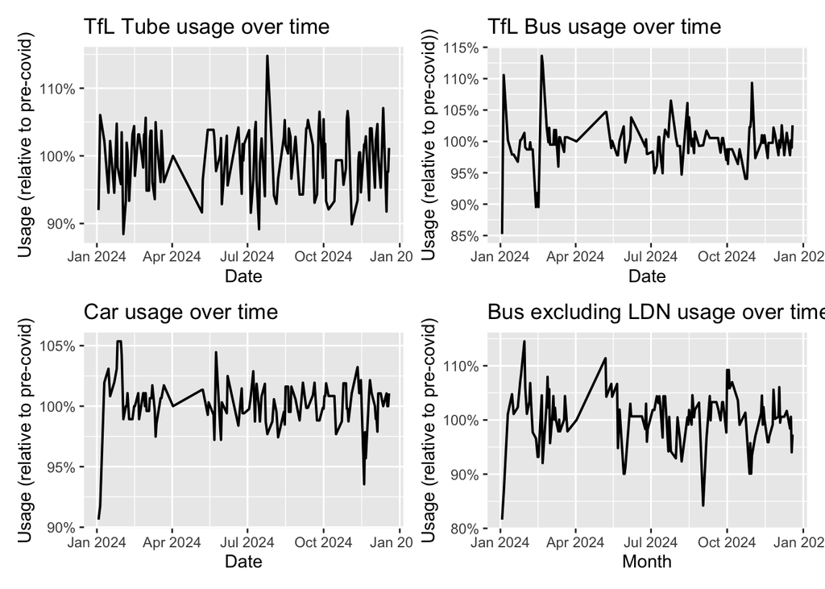

```r
# Plot the usage of tfl tubes over time
tube_plot <- ggplot(london_transport_data %>% filter(!is.na(tfl_tube)), aes(x = date)) +
  geom_line(aes(y = tfl_tube_monthly_prop), linewidth = 0.7) +
  labs(title = "TfL Tube usage over time", x = "Date", y = "Usage (relative to pre-covid)")+
  scale_y_continuous(labels = scales::percent)

# Plot the usage of tfl buses over time
bus_plot <- ggplot(london_transport_data %>% filter(!is.na(tfl_bus)), aes(x = date)) +
  geom_line(aes(y = tfl_bus_monthly_prop), linewidth = 0.7) +
  labs(title = "TfL Bus usage over time", x = "Date", y = "Usage (relative to pre-covid))") +
  scale_y_continuous(labels = scales::percent)

# Plot the usage of cars in the UK over time
car_plot <- ggplot(london_transport_data %>% filter(!is.na(cars)), aes(x = date)) +
  geom_line(aes(y = cars_monthly_prop), linewidth = 0.7) +
  labs(title = "Car usage over time", x = "Date", y = "Usage (relative to pre-covid)") +
  scale_y_continuous(labels = scales::percent)

# Plot the usage of the national rail over time
rail_plot <- ggplot(london_transport_data %>% filter(!is.na(bus_excluding_london)), aes(x = date)) +
  geom_line(aes(y = bus_excluding_london_monthly_prop), linewidth = 0.7) +
  labs(title = "Bus excluding LDN usage over time", x = "Month", y = "Usage (relative to pre-covid)") +
  scale_y_continuous(labels = scales::percent)

# Combine the plots
transport_plot <-
  tube_plot +
  bus_plot +
  car_plot +
  rail_plot +
  plot_layout(ncol = 2)

# Print the final plot
print(transport_plot)
```

The plots above demonstrate the trends in public transport usage in London and the UK over time, represented as percentages of their monthly averages (of usage levels compared to pre-covid). For instance, the plots reveal that transport usage is low at the very start of January compared to the rest of the month, but this is true for cars and buses outside of London as well as TfL tubes and buses. This allows for a visual comparison of the trends in transport usage over time.

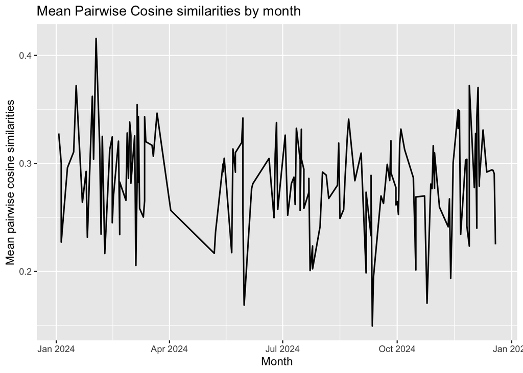

```r
# Plot the mean text similarities over time
text_plot <- ggplot(london_transport_data %>% filter(!is.na(mean_text_similarity)), aes(x = date)) +
  geom_line(aes(y = mean_text_similarity), size = 0.7) +
  labs(title = "Mean Pairwise Cosine similarities by month", x = "Month", y = "Mean pairwise cosine similarities")
print(text_plot)
```

The above plot displays the mean pairwise cosine similarities of TfL press releases for each month of 2024, providing insights into changes in public communication of initiatives over time, as measured by the mean pairwise cosine similarities between press releases. As such, the plot visually demonstrates the press releases.

## 6. London Transport Data 2024 - Accessing the data

The London Transport Data 2024, raw TfL text files, Government data, summary data and plots above are stored locally. Code to download the text files and Government data is provided in sections 2 and 3. Code to download the final dataset and outputs from section 5 is provided below. The code organises data into folders as desired. Furthermore, all data is stored remotely on GitHub.

```r
# Create subfolder for text files
outputs_subfolder <- paste0(data_folder, "outputs/")
# Check if the folder exists and create it if necessary
if(!dir.exists(outputs_subfolder)) { dir.create(outputs_subfolder) }
```

```r
# Save the final dataset
final_data_file <- paste0(data_folder, "london_transport_data_2024.csv")
# Save the final dataset if it is not already saved
if(!file.exists(final_data_file)) { write_csv(london_transport_data, final_data_file) }
```

```r
# Save the summary data
summary_data_file <- paste0(outputs_subfolder, "summary_data.csv")
# Save the summary data if it is not already saved
if(!file.exists(summary_data_file)) { write_csv(summary_data, summary_data_file) }
```

```r
# Save the plot
transport_plot_file <- paste0(outputs_subfolder, "transport_plot.png")
# Save the plot if it is not already saved
if(!file.exists(transport_plot_file)) { ggsave(transport_plot_file, transport_plot, width = 12, height = 8) }
```

```r
# Save the plot
text_plot_file <- paste0(outputs_subfolder, "text_similarities_plot.png")
# Save the plot if it is not already saved
if(!file.exists(text_plot_file)) { ggsave(text_plot_file, text_plot, width = 12, height = 8) }
```